# Exome capture vs chr21 capture statistics

Harrison Ostridge

2024-03-18

Josh highlighted the technical differences between exome and chr21 capture data could mae using chr21 as a null problematic. Here I compare the allele frequency estimates and coverage for exomes on the chr21 from the exome capture and chr21 capture. Although we of course only use the non-genic regions as a null, comparing the exonic regions should highlight differences that arise due to the differnt in the capture techniques.

The purpose if this script is to plot the SFS for exomes on chr21 from both the exome and chr21 capture data to check for discrepancies.

#### Setup

#### Parameters

#### Library

### Bedtools - extract chr21 exonic SNPs

Claudia emailed a zip containing coordinates of on target regions (26/03/2021) used to target and sequence the exomes currently at `~/OneDrive - University College London/Projects/PanAf/phase1and2_exomes/data/exome_coordinates/`. The covered and regions files are apparently the same according to the file headers - I decided to use regions just because in the file it uses “target regions” which is the terminology everyone uses.

```bash
# Remove the header lines
awk 'NR > 2 { print }' ../genomic_data/exome_coordinates/S07604514/S07604514_Regions.bed | sed 's/chr//g' > output/S07604514_Regions_no.head.bed

# BEDtools intersect
  for SUBSP in '' '.ce' '.n' '.w'
  do
    echo ${SUBSP}

    if [[ "$SUBSP" == ".n" ]]
     then
      MISS_POP=0
      MISS_POP2=0.0
    else
      MISS_POP=0.3
      MISS_POP2=0.3
    fi
    # chr21
   tail -n +2 chr21/output/chr21.f7${SUBSP}.pops_minInd.6or50pct_missing.pops.${MISS_POP}/chr21.f7${SUBSP}.pops_chr21_missing.pops.${MISS_POP2}_pop.allele.counts_minMAC2 | awk -F "\t" 'OFS="\t" { print $1,$2,($2 + 1) }' | sed 's/chr//g' > output/chr21.f7${SUBSP}.pops_chr21_missing.pops.${MISS_POP}_minMAC2.bed

    bedtools intersect \
    -a output/chr21.f7${SUBSP}.pops_chr21_missing.pops.${MISS_POP}_minMAC2.bed \
    -b  output/S07604514_Regions_no.head.bed \
    | awk -F "\t" 'OFS="\t" { print $1,$2 }' > output/chr21.f7${SUBSP}.pops_chr21_missing.pops.${MISS_POP}_minMAC2_exonic.snps

    # Exome
    tail -n +2 exome/output/f5${SUBSP}.pops_minInd.6or50pct_missing.pops.${MISS_POP}/f5${SUBSP}.pops.all.chrs_missing.pops.${MISS_POP}_pop.allele.counts_minMAC2 | awk -F "\t" 'OFS="\t" { print $1,$2,($2 + 1) }' | sed 's/chr//g' > output/f5${SUBSP}.pops_missing.pops.${MISS_POP}_minMAC2.bed

    bedtools intersect \
    -a output/f5${SUBSP}.pops_missing.pops.${MISS_POP}_minMAC2.bed \
    -b  output/S07604514_Regions_no.head.bed \
    | awk -F "\t" 'OFS="\t" { print $1,$2 }' > output/f5${SUBSP}.pops_missing.pops.${MISS_POP}_minMAC2_exonic.snps
  done
```

```
##
## .ce
## .n
## .w
```

# Allele frequncy estimates from ANGSD

## Same regions (chr21 exons)

## Same SNPs

### SFS

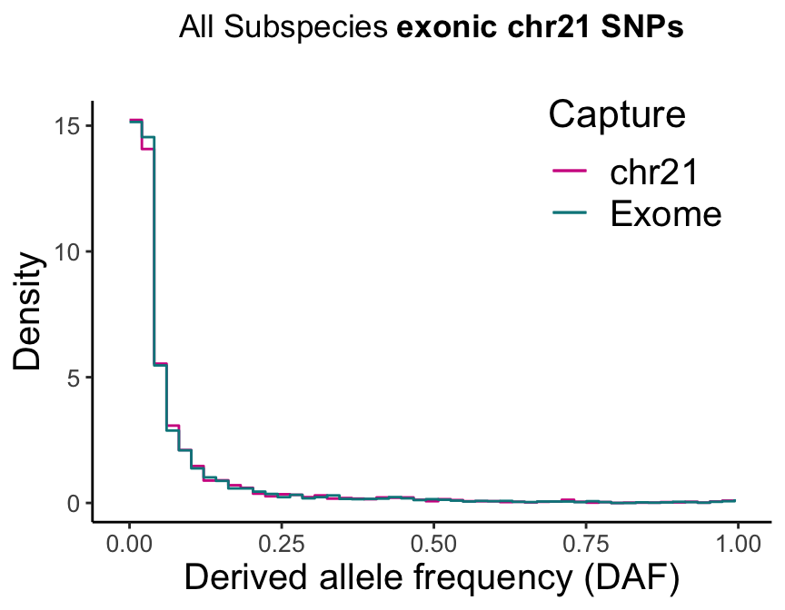

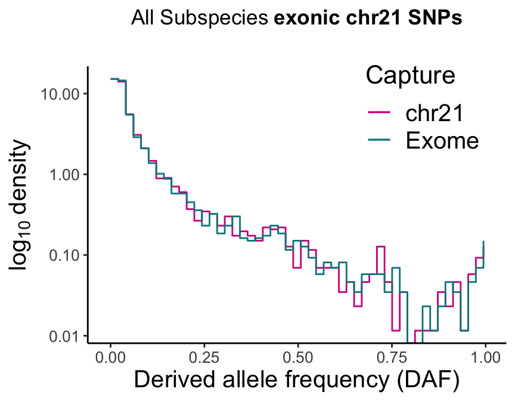

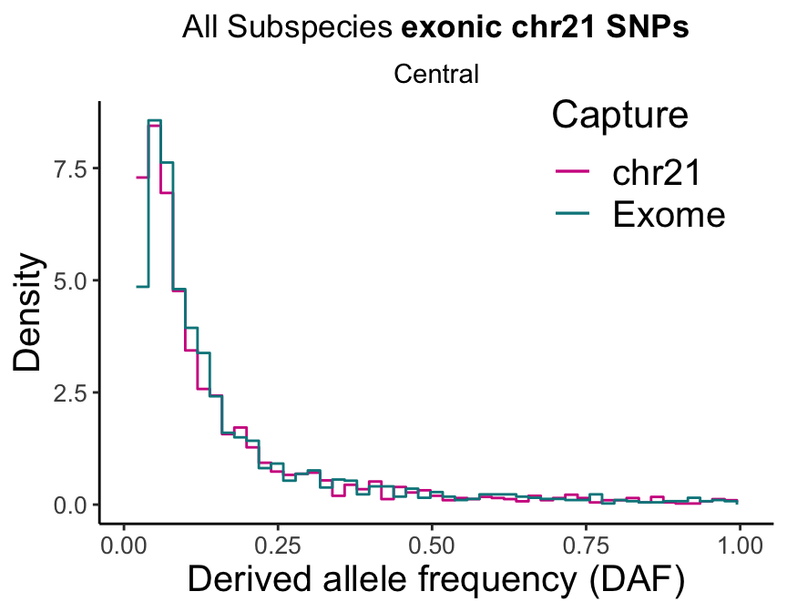

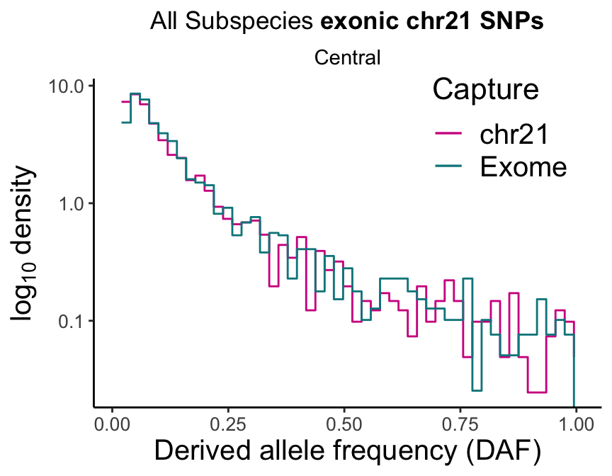

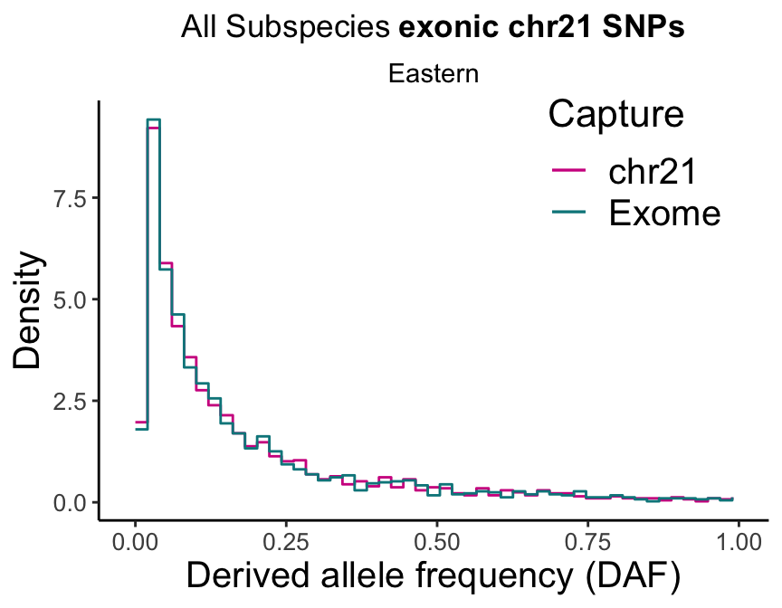

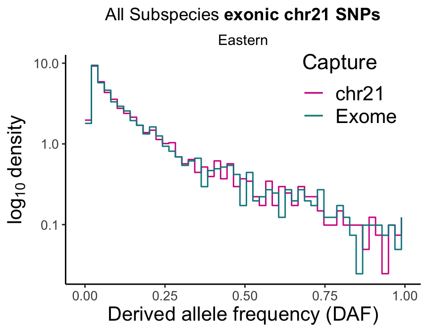

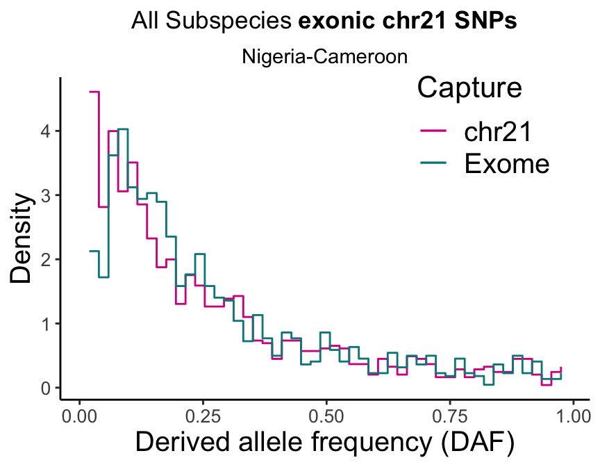

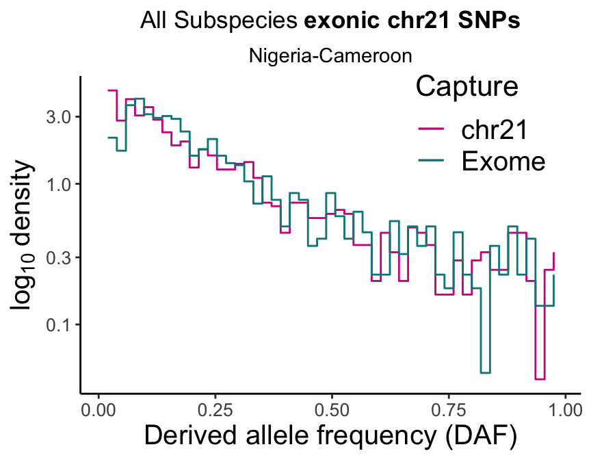

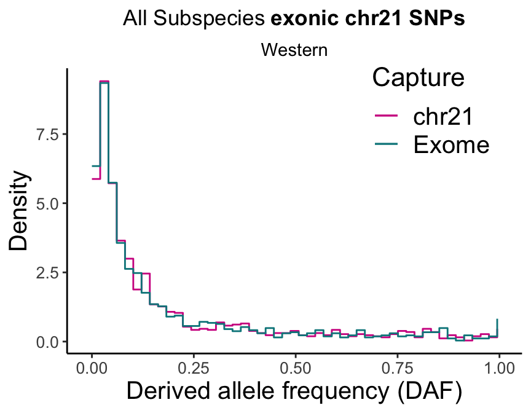

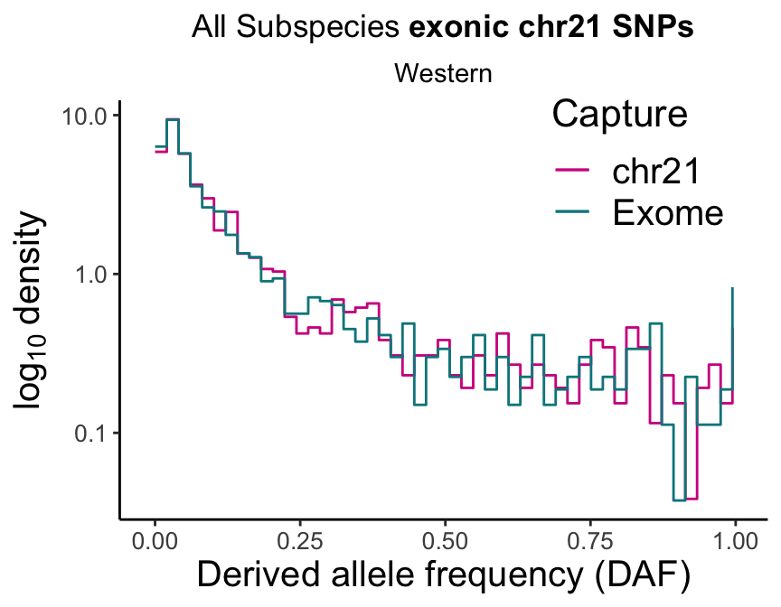

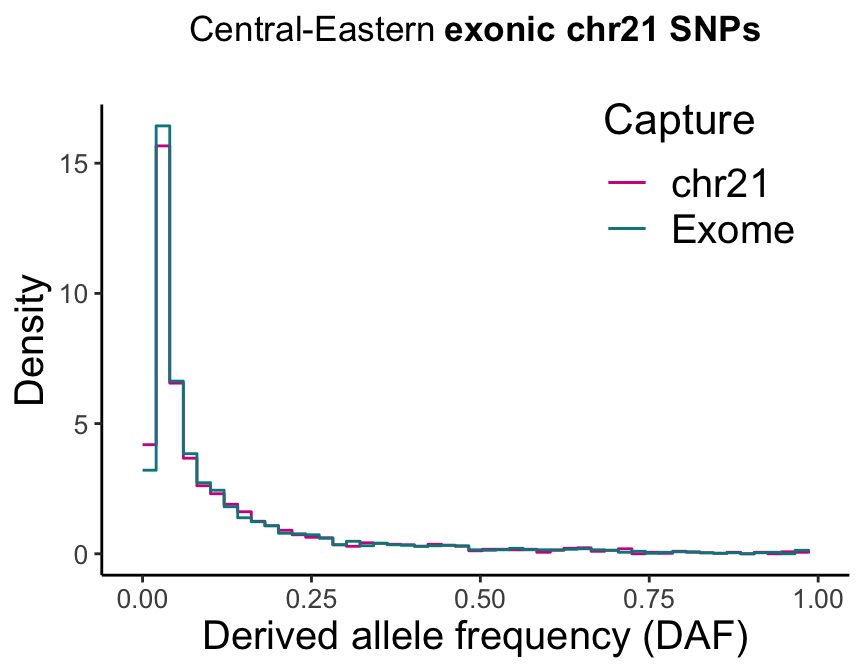

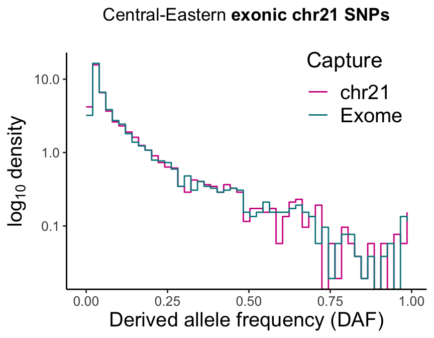

[8 more figures not shown]

### Exome capture vs chr21 capture AF estimates

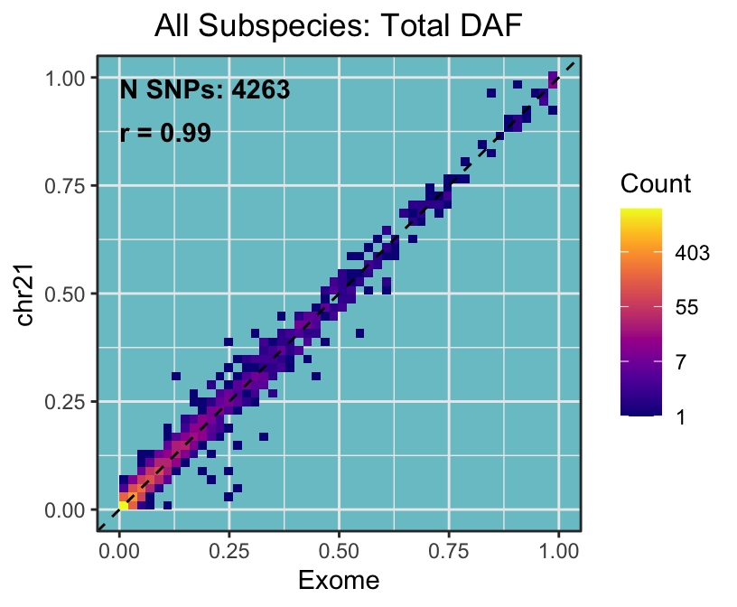

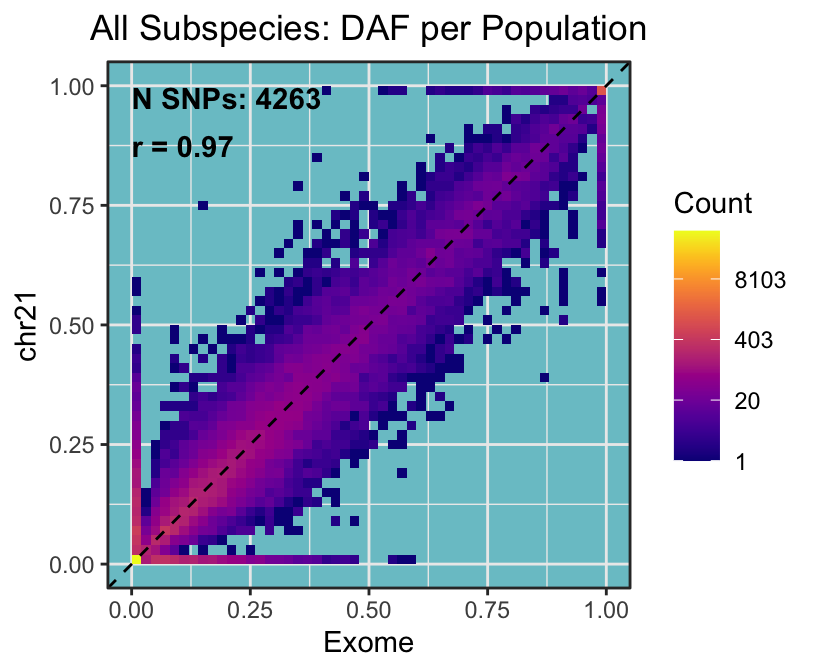

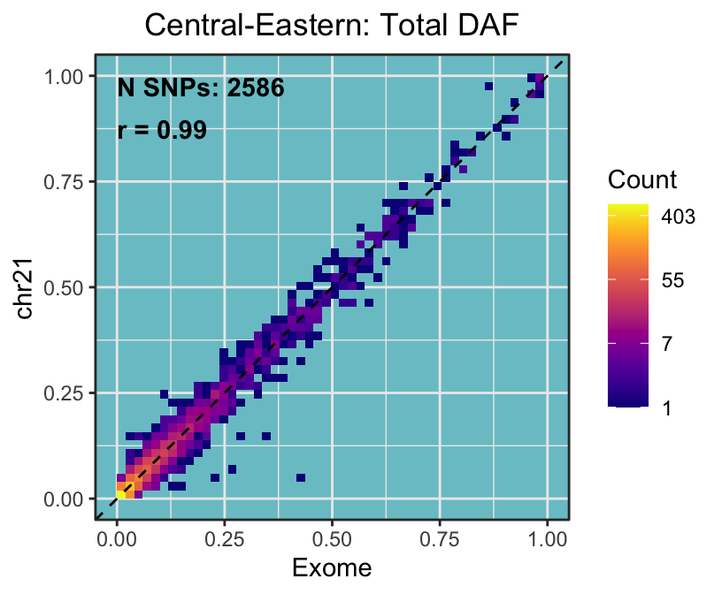

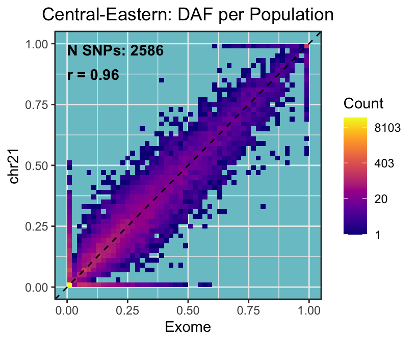

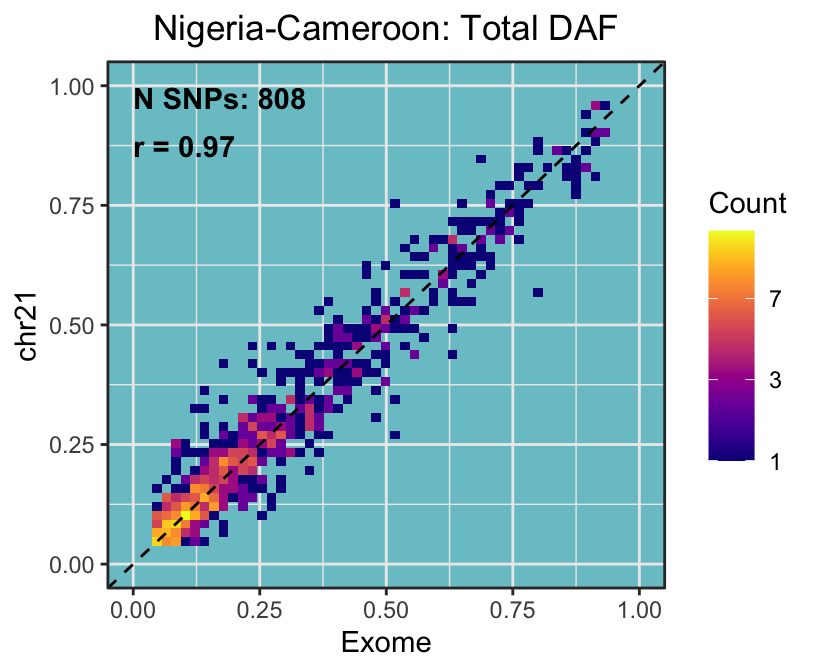

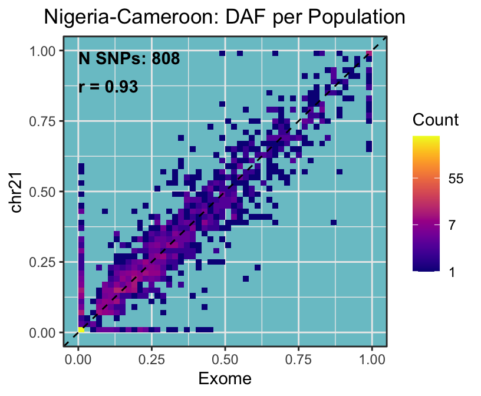

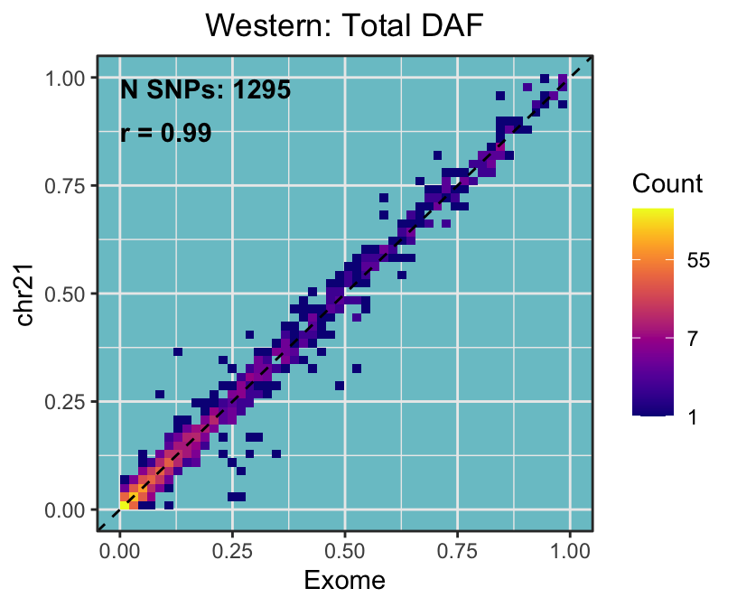

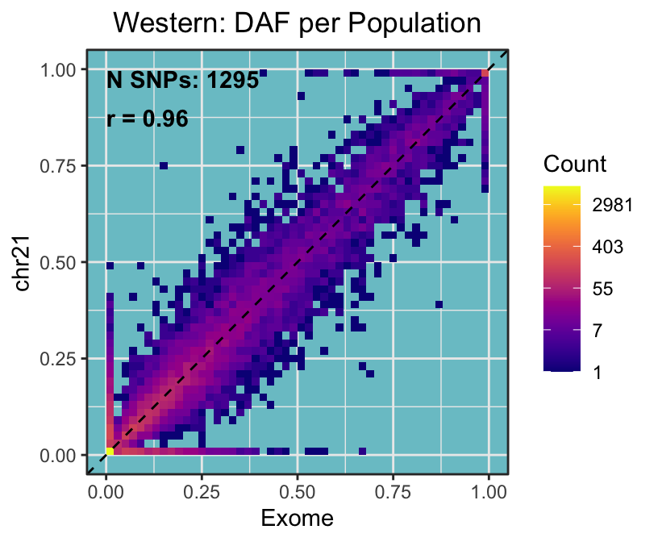

The line of best fit does have a slope slightly less than 1.

### Difference

# Coverage

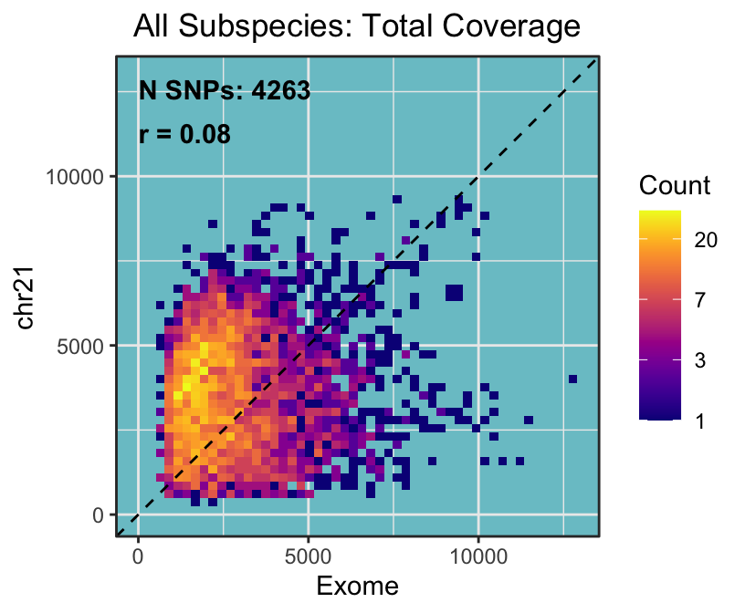

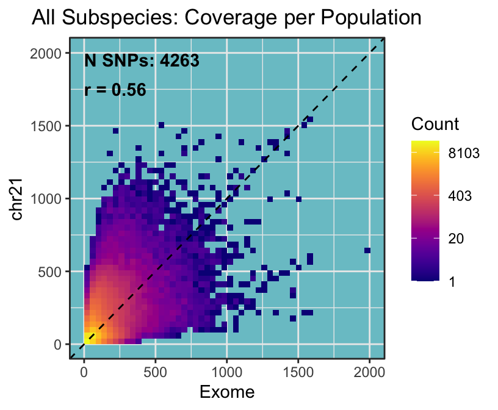

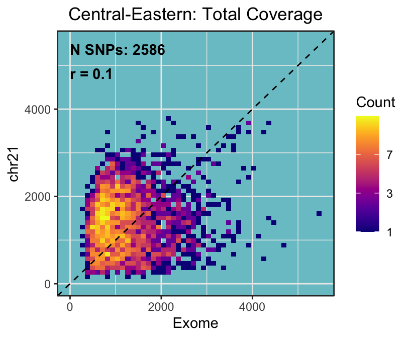

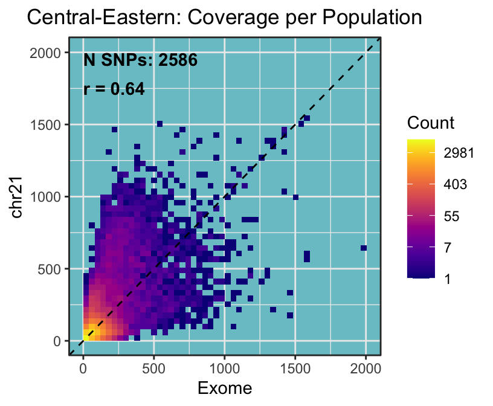

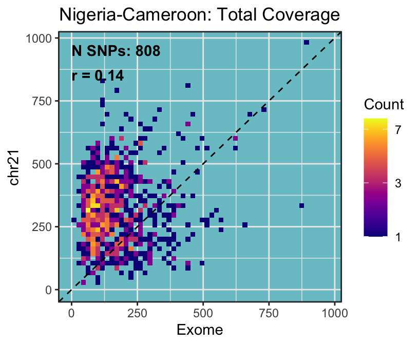

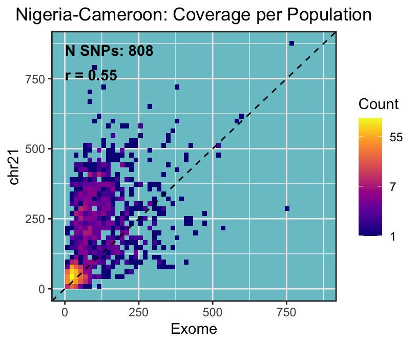

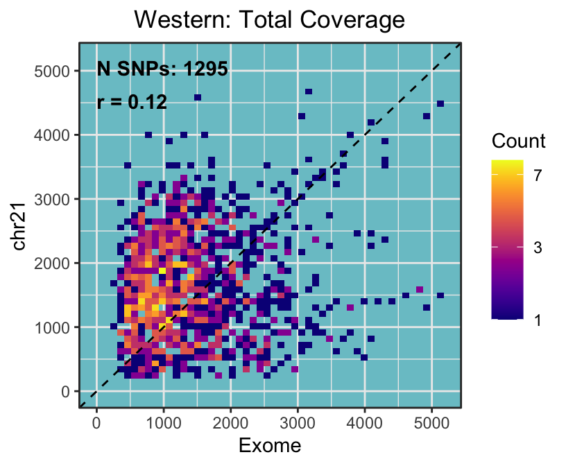

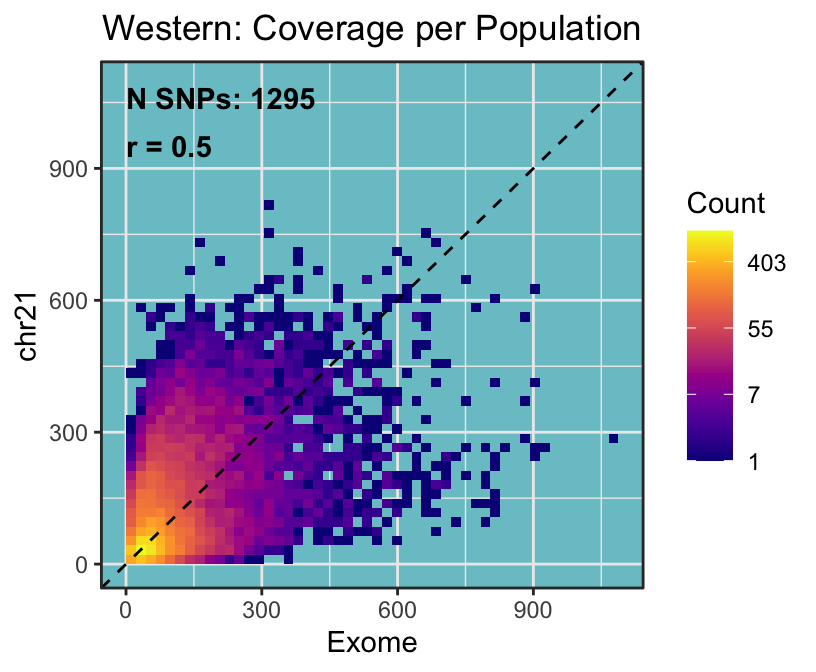